# Burden Testing for Germline Variants in Pediatric AML

2025-04-08

The following documentation shows the methodology for burden testing of germline variants in pediatric acute myeloid leukemia as compared to healthy controls from the 1000 Genomes Project, as described in Harmon, et. al, 2025: “Germline Variant Burden Warrants Universal Genetic Testing in Pediatric Myeloid Leukemia”.

## Background: Burden Testing for Germline Predisposition Variants

We used burden testing to analyze the contributions of inherited germline variants to disease risk, comparing the frequency of how often these variants occur in patients as compared to a general population. Burden testing offers an advantage over comparing individual variants, since many deleterious variants are rare. By aggregating by gene or groups of genes, this increases statistical power to determine overall significance. Here, we employ burden testing by comparing how many putative loss of function (pLOF) variants occur in genes that are related to AML predisposition, with the hypothesis that AML patients will have more pLOF variants than the general population. We used healthy control subjects from the 1000 Genomes Project as the control population. We looked at genes that are thought to contribute to AML predisposition as well as randomly-selected genes. The following files contain pLOF variants with a GnomAD frequency < 0.001 for these genes in AML and control subjects, as determined using Ensemble’s Variant Effect Predictor.

Load the data and covariates.

```r
library(tidyverse)
aml <- read_tsv("candidate_aml_genes_lof_variants.tsv")
random <- read_tsv("random_genes_lof_variants.tsv")

#Split the AML genes into genes that are established in the literature to be
#involved in predisposition and candidate genes.
established.genes <- read_csv("established_myeloid_genes.csv")
est.ad <- established.genes[grepl("AD",established.genes$Inheritance),]

aml.est <- aml[aml$SYMBOL %in% established.genes$Gene,]
aml.est$Sample_Gene <- paste0(aml.est$sampleNames,"_",aml.est$SYMBOL)
table(aml.est$Sample_Gene) %>% sort()
```

```
##
##   HG00173_RTEL1   HG00288_RASA2   HG00345_TINF2   HG00472_FANCA   HG01377_BRCA2
##               1               1               1               1               1
##   HG01697_FANCF   HG01747_RTEL1   HG01761_FANCF    HG01812_MSH2   HG01862_EPCAM
##               1               1               1               1               1
##   HG01894_FANCI   HG01965_FANCG    HG02111_CTC1   HG02450_RASA2   HG02840_FANCG
##               1               1               1               1               1
##   HG02881_FANCG   HG03428_FANCI   HG04212_FANCM     NA12414_CBL   NA18499_RTEL1
##               1               1               1               1               1
## NA18563_ANKRD26   NA19067_RASA2   NA19130_FANCM NA19225_ANKRD26   NA19684_RTEL1
##               1               1               1               1               1
##     PAUHFI_PMS2    PAUKTH_SAMD9    PAUWKY_GATA2    PAUXKI_BRCA2    PAUYAE_SAMD9
##               1               1               1               1               1
##    PAVAVV_FANCL  PAVBNV_ANKRD26   PAVBUX_FANCD2    PAVDVU_SAMD9     PAVHCV_PMS2
##               1               1               1               1               1
##    PAVHWK_BRCA2     PAVIGB_CTC1    PAVKAU_BRCA2    PAVLJH_RASA2     PAVSAN_MSH6
##               1               1               1               1               1
##   PAVTDU_RAD51C    PAWAMB_FANCA
##               1               1
```

```r
#Since there are no double hits we only need to consider genes with dominant inheritance
#for the established group.
aml.est <- aml.est[aml.est$SYMBOL %in% est.ad$Gene,]
aml.cand <- aml[!aml$SYMBOL %in% est.ad$Gene,]

samples <- read_tsv("samples_disease_status.txt")
```

Calculate odds ratios and confidence intervals for each group of genes using a binomial model.

```r
calcOddsRatio <- function(df){
  counts <- samples %>% dplyr::select(sampleNames,disease)
  counts$variant <- as.vector(table(df$sampleNames)[counts$sampleNames])
  counts$variant[is.na(counts$variant)] <- 0
  counts$variant[counts$variant >1] <- 1
  counts$disease <- as.factor(counts$disease)
  binom.fit <- glm(variant ~ disease, data=counts, family=binomial)
  library(questionr)
  print(odds.ratio(binom.fit))
}

calcOddsRatio(aml.est)
```

```
##                    OR     2.5 %  97.5 %         p
## (Intercept) 0.0056225 0.0031634  0.0091 < 2.2e-16 ***
## diseasepAML 7.1583370 3.2947408 15.4455 4.394e-07 ***
## ---
## Signif. codes:  0 '***' 0.001 '**' 0.01 '*' 0.05 '.' 0.1 ' ' 1
```

```r
calcOddsRatio(aml.cand)
```

```
##                   OR    2.5 % 97.5 %         p
## (Intercept) 0.071918 0.061272 0.0838 < 2.2e-16 ***
## diseasepAML 2.430902 1.718108 3.3876 2.763e-07 ***
## ---
## Signif. codes:  0 '***' 0.001 '**' 0.01 '*' 0.05 '.' 0.1 ' ' 1
```

```r
calcOddsRatio(random)
```

```
##                   OR    2.5 % 97.5 %       p
## (Intercept) 0.060119 0.050531 0.0709 < 2e-16 ***
## diseasepAML 1.690649 1.108112 2.5048 0.01133 *
## ---
## Signif. codes:  0 '***' 0.001 '**' 0.01 '*' 0.05 '.' 0.1 ' ' 1
```

The odds ratio for established AML genes is 7.2 (95% CI: (3.3, 15.4)). The p-value for established AML genes between pAML patients and 1KG controls is 4.394e-07.

The odds ratio for candidate AML genes is 2.4 (95% CI: (1.7,3.4)). The p-value for candidate AML genes between pAML patients and 1KG controls is 2.763e-07.

The odds ratio for randomly-selected genes is 1.7(95% CI: (1.1,2.5)). The p-value for randomly-selected genes between pAML patients and 1KG controls is 0.01133.

This shows that pLOF variants are enriched in AML patients, most notably in genes that are established or candidate for AML predisposition.

Now compute odds ratio and confidence intervals using resampling.

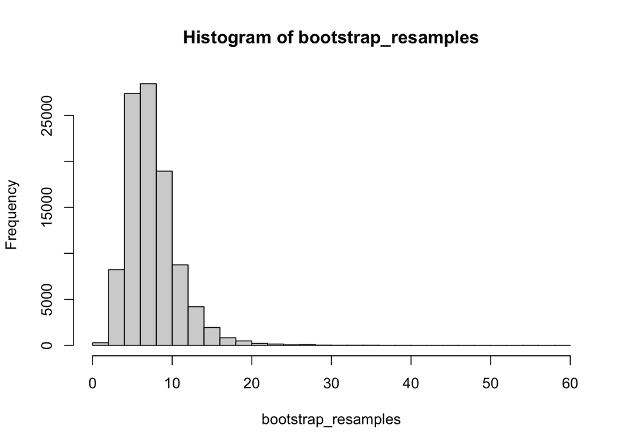

```
##      2.5%       50%     97.5%
##  3.068627  6.920068 14.904762
```

```r
bootstrap_resample <- function(controlCounts,amlCounts) {
  control_size <- nrow(controlCounts)
  control_sample <- controlCounts[sample(seq(1:nrow(controlCounts)), size = control_size, replace=TRUE),]
  aml_size <- nrow(amlCounts)
  aml_sample <- amlCounts[sample(seq(1:nrow(amlCounts)), size = aml_size, replace=TRUE),]
  mean_control <- mean(control_sample$n)
  mean_aml <- mean(aml_sample$n)
  OR <- mean_aml / mean_control
  return(OR)
}

processResamples <- function(df){
  bySample <- df %>% group_by(sampleNames,disease) %>% summarize(n=n())
  sampleCounts <- left_join(samples,bySample)
  sampleCounts$n[is.na(sampleCounts$n)] <- 0
  controlCounts <- sampleCounts[sampleCounts$disease == "Control",]
  amlCounts <- sampleCounts[sampleCounts$disease == "pAML",]
  bootstrap_resamples <- replicate(100000,bootstrap_resample(controlCounts=controlCounts,amlCounts=amlCounts))
  #Make sure that the histogram looks normal
  hist(bootstrap_resamples,breaks=25)

  #Get the estimate and 95% confidence interval
  print(quantile(bootstrap_resamples, c(.025, .5, .975)))
}

set.seed(1234)
resamples_est <- processResamples(aml.est)
```

```r
resamples_cand <- processResamples(aml.cand)
```

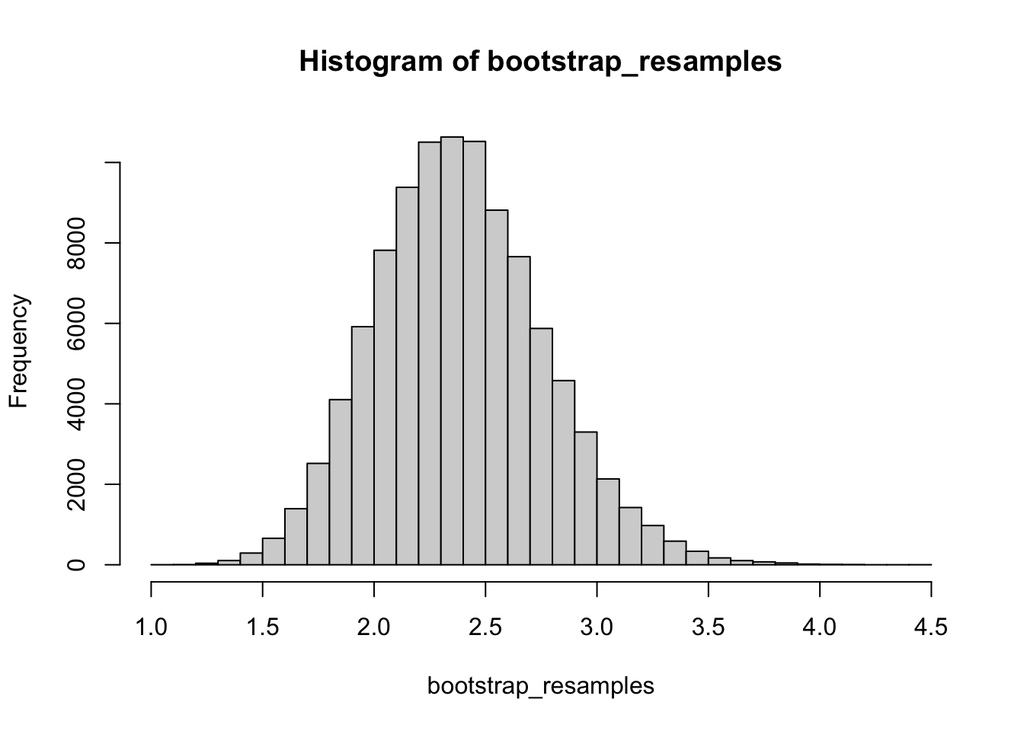

```
##     2.5%      50%    97.5%
## 1.701087 2.369254 3.181915
```

```r
resamples_random <- processResamples(random)
```

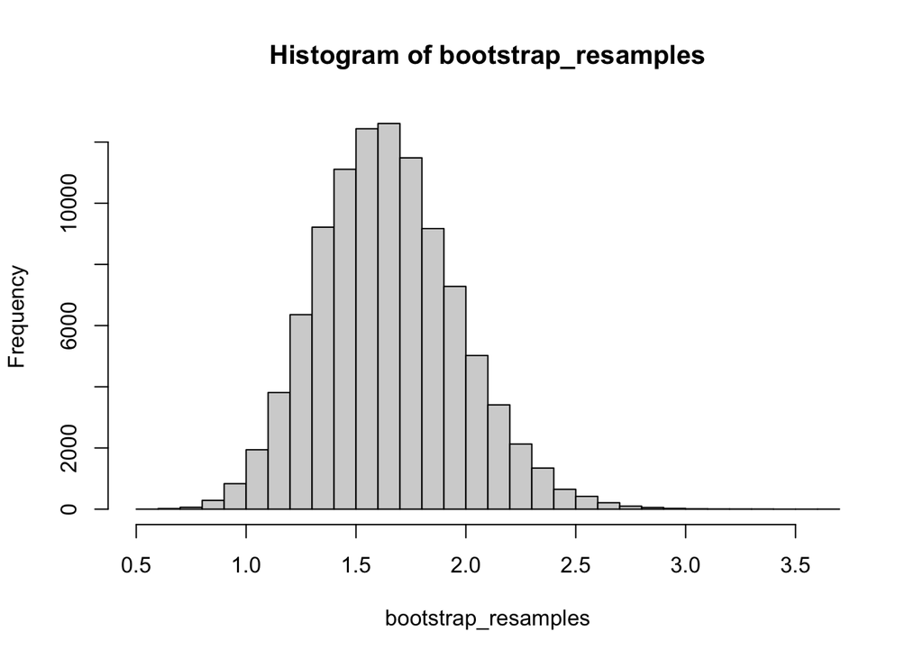

```
##     2.5%      50%    97.5%
## 1.072691 1.628666 2.318519
```

The odds ratio based on bootstrap resampling for established AML genes is 6.9 (95% CI: (3.1, 14.9)).

The odds ratio based on bootstrap resampling for candidate AML genes is 2.4 (95% CI: (1.7,3.2)).

The odds ratio based on bootstrap resampling for randomly-selected genes is 1.6(95% CI: (1.1,2.3)).

The confidence intervals are very similar using the binomial method as bootstrap resampling.

## Resampling-based inference of germline burden

Now, we perform resampling to compare the percentage of subjects with a germline variant in each of these groups of genes.

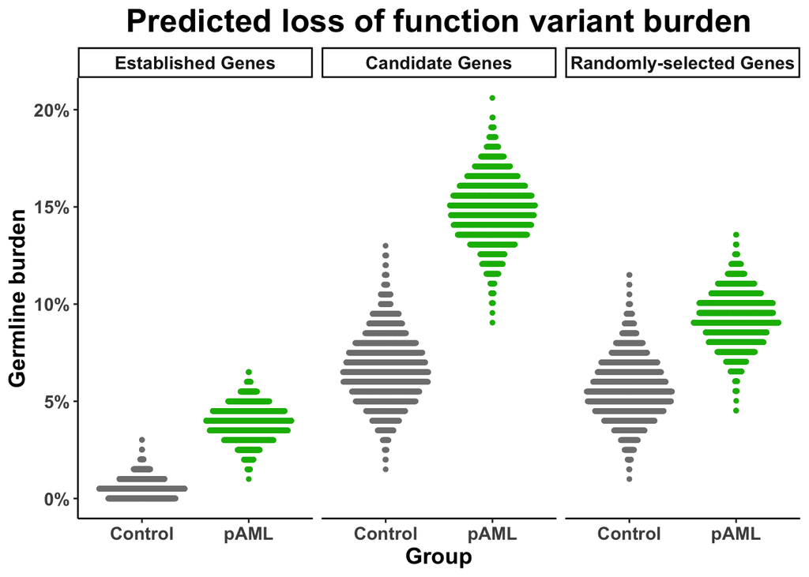

```r
set.seed(1234)
library(reshape2)
rs <- function(y, n, m, slop=20) {
  s <- n + (round(slop/2)) - sample(seq_len(slop), 1)
  replicate(m, sum(y[sample.int(n=length(y), size=s)] > 0) / s)
}

processData <- function(df){
  bySample <- df %>% group_by(sampleNames,disease) %>% summarize(n=n())
  sampleCounts <- left_join(samples,bySample)
  sampleCounts$n[is.na(sampleCounts$n)] <- 0

  byGroup <- split(sampleCounts$n, sampleCounts$disease)
  res <- data.frame(lapply(byGroup, rs, n=200, m=3000, slop=2))
  results <- melt(res, variable.name="Group", value.name="Burden")
}

results_est <- processData(aml.est)
results_cand <- processData(aml.cand)
results_random <- processData(random)
results_est$Region <- "Established Genes"
results_cand$Region <- "Candidate Genes"
results_random$Region <- "Randomly-selected Genes"
res_combined <- rbind(results_est,results_cand,results_random)
res_combined$Region <- factor(res_combined$Region,levels=c("Established Genes","Candidate Genes","Randomly-selected Genes"))

res_combined$Group <- gsub("random","1KG (randoms)",res_combined$Group)
library(ggbeeswarm)
library(ggsignif)

grp.colors <- c("1000 Genomes Subject"="gray","pAML"="#0CB702")
ggplot(res_combined, aes(x=Group, y=Burden, color=Group)) +
  scale_y_continuous(labels = scales::percent)+
  facet_wrap(~Region) +
  ggtitle(paste("Predicted loss of function variant burden"))+
  ylab("Germline burden") +
  geom_quasirandom(size=1) +
  theme_classic() +
  theme(legend.position="none",plot.title = element_text(hjust = 0.5))+
  theme(text = element_text(face="bold", size = 14))+
  theme(plot.title=element_text(face="bold",size=20))+
  scale_color_manual(values =grp.colors)
```

Pediatric AML patients have a higher frequency of loss of function variants in all of the gene categories, and this difference is most distinct in established predisposition genes and in candidate predisposition genes.

## Testing the Fanconi Anemia pathway

Here, we use burden testing to test for an enrichment of germline pLOF variants in the Fanconi Anemia (FA) pathway. The FA pathway performs DNA double-stranded break repair and is frequently mutated in cancer. Many of these genes have been implicated in cancer predisposition, most notably in breast cancer. Here, we examine only the FA genes that are known to confer increased breast cancer risk in the autosomal dominant form to determine if they also have an increased burden in pediatric AML patients.

```r
fa_genes <- c("BRCA1","BRCA2","BRIP1","FANCB","PALB2","RAD50","RAD51","RAD51C","RAD51D")
fa_variants <- aml[aml$SYMBOL %in% fa_genes,]

bySample <- aml %>% group_by(sampleNames,disease) %>% summarize(n=n())
sampleCounts <- left_join(samples,bySample)
sampleCounts$n[is.na(sampleCounts$n)] <- 0
fa_counts <- sampleCounts %>% dplyr::select(sampleNames,disease)
fa_counts$fa_variant <- 0
fa_counts$fa_variant[fa_counts$sampleNames %in% fa_variants$sampleNames] <- 1
print(table(fa_counts$fa_variant,fa_counts$disease))
```

```
##
##     Control pAML
##   0    2502  330
##   1       2    6
```

```r
print(table(fa_variants$SYMBOL,fa_variants$disease))
```

```
##
##          Control pAML
##   BRCA2        1    3
##   BRIP1        0    1
##   PALB2        1    0
##   RAD50        0    1
##   RAD51C       0    1
```

```r
#Chi-square test between pediatric AML and controls
print(chisq.test(fa_counts$fa_variant,fa_counts$disease))
```

```
##
##  Pearson's Chi-squared test with Yates' continuity correction
##
## data:  fa_counts$fa_variant and fa_counts$disease
## X-squared = 24.917, df = 1, p-value = 5.986e-07
```

```r
#Calculate odds ratio
fa_counts$disease <- as.factor(fa_counts$disease)
fa.binom.fit <- glm(disease ~ fa_variant, data=fa_counts, family=binomial)
library(questionr)
print(odds.ratio(fa.binom.fit))
```

```
##                   OR    2.5 %   97.5 %         p
## (Intercept)  0.13189  0.11739   0.1477 < 2.2e-16 ***
## fa_variant  22.74545  5.21619 155.6794 0.0001352 ***
## ---
## Signif. codes:  0 '***' 0.001 '**' 0.01 '*' 0.05 '.' 0.1 ' ' 1
```

# Discussion

The results of these burden tests strongly support the hypothesis that pediatric AML patients have a higher burden of deleterious loss of function variants, especially in genes with candidate or established roles in AML predisposition.